# 3-relevance

# The concept

## An example

Imagine that we are dealing with Gaia RVS spectra:

These spectra are characterized by a wavelength coverage of 845–872 nm with R=11500.

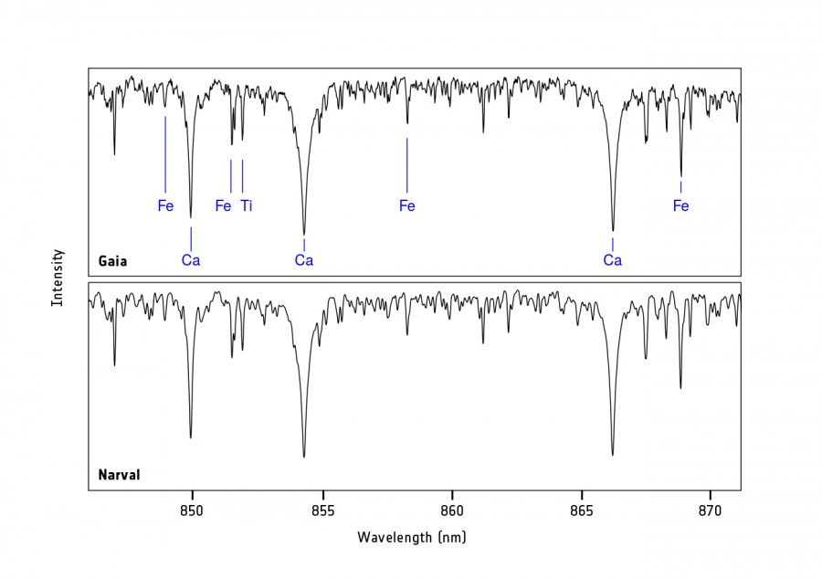

As you can see, the range is small but contains a number of spectral lines that are important diagnostics of the thermodynamic state of the stellar atmosphere.

Let us leave the physical analysis of the spectral lines for now and concentrate in the problem of handling feature spaces of the size of an RVS spectrum. It typically contains circa 10^{4} fluxes, many of which contain no information about the stellar physical parameters. This represents a 10^{4}-dimensional space.

Now, imagine a set of example RVS spectra from stars of many different temperatures (surface gravities, metallicities…). Our aim is to construct a model that predicts temperatures from an observed spectrum. Let us do it using one of the most simple models at hand: the k-nearest neighbours (kNN). kNN will receive an observed spectrum and look for the k closest spectra in the set of examples. What do you think would be a reasonable value for k? Let us start with k=1: we will attach to the observed spectrum the temperature of the example that is closest in some to-be-determined sense.

Now, for the sake of clarity, let us rescale each observed flux between 0 and 1. This is not necessary, but helps visualize the problem. We, of course, use the same rescaling for the observed spectrum and for the training set.

After rescaling, our data set occupies a hypercube of 10^{4}dimensions with unit side.

Now, let us ask ourselves how many examples do we need to ensure that the closest example (in the to-be-determined sense) is not further than one particular example: one example that differs from our observed spectrum by a 10% in each flux.

If our spectra had only 2 measured fluxes, this furthest allowed example would be at a distance equal to $\sqrt{0.1^2+0.1^2}$=0.1414214.

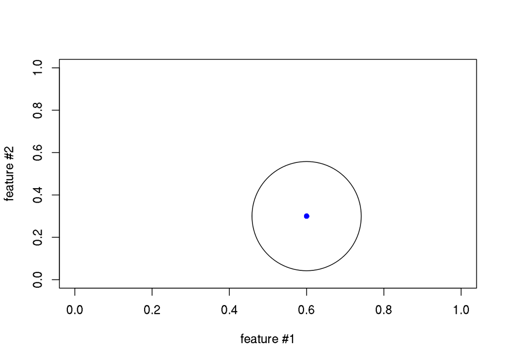

```r
plot(cbind(0,0),xlim=c(0,1),ylim=c(0,1),xlab="feature #1",ylab="feature #2",col="white")
points(cbind(0.6,0.3),pch=16,col="blue")
r <- sqrt(0.1^2+0.1^2)
draw.circle(0.6,0.3,r)
```

How many examples do we need to ensure that there is always an example within a radius of 0.1414214? Well, the total area of the square is 1, and that of the circle is *π* * *r*<sup>2</sup>=0.0628319 so we need $\frac{1}{\pi*r^2}$=15.9154943.

That is roughly 16 examples distributed homogeneously in the 2D square.

Let us now look at the true RVS space. The hypercube volume still is 1, but the volume of the hypersphere in *n* dimensions is now $\frac{2\cdot r^d*\pi^{n/2}}{\Gamma(n/2)}$. Our RVS spectra have 10^{4} fluxes, so if we still enforce that the farthest example is at most at a 10% in each dimension, the examples have to be closer than  
$d=\sqrt{\sum_{i=1}^{10000} 0.1^2}.$  
That is, there has to be an example at a distance d<10.

How many examples do we need to ensure that there is at least one within a circle of radius 10?

A hypersphere in 10^{4} dimensions of radius 10 has a volume equal to

```r
r <- sqrt(10000*0.1^2)
logVsphere <- log(2)+n*log(r)+(n/2)*log(pi)-lgamma(n/2)
print(logVsphere)
```

```
## [1] -8832.433
```

So (in the hypothesis of training examples distributed homogeneously in the hypercube), we would need

So if we go kNN, it is unthinkable that we can gather a large enough set of training examples such that the closest example is at a distance shorter than that implied by a 10% difference in each feature. A10%! That is a lot.

There are other ways to visualize this curse-of-dimensionality. But in practice they all imply an exponentially increasing training set size with increasing space dimensionality. Or conversely, it implies that for a fixed training set size, the predictive power degrades with the dimensionality of the space (the so-called Hughes phenomenon).

# The concept

Once we have seen that high-dimensional spaces can be a curse, we need criteria to reduce the dimensionality of the input space without losing important information. And here is the difficult bit: to go from the loose semantic content of “important” to something that can be made reproducible and analytic.

The two concepts that are key to this notebook are relevance and redundancy

# The example

Let us play with a toy problem in which our feature space is composed of 5 boolean variables (*X*<sub>1</sub>, *X*<sub>2</sub>, *X*<sub>3</sub>, *X*<sub>4</sub>, and, *X*<sub>5</sub>) and the class is defined as  
*C* = *X*<sub>1</sub> ⊕ *X*<sub>2</sub> ⊕ *X*<sub>3</sub>  
.

Then, *X*<sub>4</sub> is defined as *X*<sub>2</sub> ⊕ *X*<sub>3</sub>. Finally, *X*<sub>5</sub> is a random variable that takes boolean values independent of any of the other variables *X*<sub>1</sub> − *X*<sub>4</sub>. Therefore, the class is independent of *X*<sub>5</sub>.

Here you have the only 16 possible examples:

| x1 | x2 | x3 | x4 | x5 | class |
| --- | --- | --- | --- | --- | --- |
| 0 | 0 | 0 | 0 | 0 | 0 |
| 1 | 0 | 0 | 0 | 0 | 1 |
| 0 | 1 | 0 | 1 | 0 | 1 |
| 1 | 1 | 0 | 1 | 0 | 0 |
| 0 | 0 | 1 | 1 | 0 | 1 |
| 1 | 0 | 1 | 1 | 0 | 0 |
| 0 | 1 | 1 | 0 | 0 | 0 |
| 1 | 1 | 1 | 0 | 0 | 1 |
| 0 | 0 | 0 | 0 | 1 | 0 |
| 1 | 0 | 0 | 0 | 1 | 1 |
| 0 | 1 | 0 | 1 | 1 | 1 |
| 1 | 1 | 0 | 1 | 1 | 0 |
| 0 | 0 | 1 | 1 | 1 | 1 |
| 1 | 0 | 1 | 1 | 1 | 0 |
| 0 | 1 | 1 | 0 | 1 | 0 |
| 1 | 1 | 1 | 0 | 1 | 1 |

This is a very simple, artificial example defined to illustrate some of the key concepts of dimensionality reduction. From God’s perspective, the solution is clear: keep *X*<sub>1</sub> and *X*<sub>4</sub> and make sure that your model is capable of capturing highly non-linear and disconnected boundaries such as those implied by this problem.

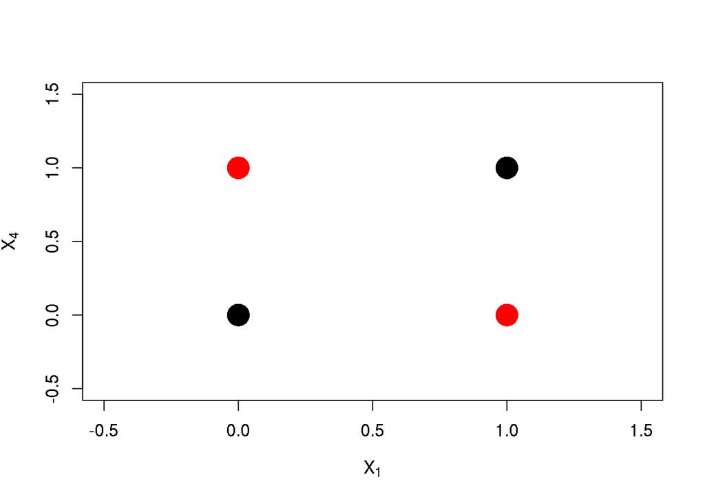

```r
plot(cases[,1],cases[,4],xlab=expression(X[1]), ylab=expression(X[4]),pch=16,cex=3,col=class+1,xlim=c(-.5,1.5), ylim=c(-.5,1.5))
```

The set {*X*<sub>1</sub>, *X*<sub>4</sub>} is at the same time sufficient and minimal. There are other alternatives: {*X*<sub>1</sub>, *X*<sub>2</sub>, *X*<sub>3</sub>} is sufficient (but not minimal). There is redundancy between *X*<sub>2</sub>, *X*<sub>3</sub>*a**n**d**X*<sub>4</sub>, and *X*<sub>5</sub> is completely irrelevant for the determination of the class. Unfortunately, we hardly ever are God sitting on a cloud, and we never know an analytical expression for the class.

Now, for the definitions. This is the particular set I (and a vast majority of the community) agree with. There are [alternatives](https://www.researchgate.net/profile/Ron_Kohavi/publication/223713209_Wrappers_for_Feature_Subset_Selection/links/02e7e51bcc03dd7eef000000.pdf?origin=publication_detail), of course.

- *Y* represents the target variable, while *y* represents a particular possible value.
- *X* represents features (random variables), while *s* represent particular values of the variable
- Let *S*<sub>*i*</sub> be the set of all features except *X*<sub>*i*</sub>
- Let *S*′<sub>*i*</sub> be a subset of *S*<sub>*i*</sub>
- A feature *X*<sub>*i*</sub> is strongly relevant if and only if there exists *x*<sub>*i*</sub>, *y*, and *s*<sub>*i*</sub> for which  
  *p*(*X*<sub>*i*</sub> = *x*<sub>*i*</sub>, *S*<sub>*i*</sub> = *s*<sub>*i*</sub>) > 0  
  such that  
  *p*(*Y* = *y*|*X*<sub>*i*</sub> = *x*<sub>*i*</sub>, *S*<sub>*i*</sub> = *s*<sub>*i*</sub>) ≠ *p*(*Y* = *y*|*S*<sub>*i*</sub> = *s*<sub>*i*</sub>)
- A feature *X*<sub>*i*</sub> is weakly relevant if and only if it is not strongly relevant and there exists *x*<sub>*i*</sub>, *y*, and *s*′<sub>*i*</sub> for which  
  *p*(*X*<sub>*i*</sub> = *x*<sub>*i*</sub>, *S*′<sub>*i*</sub> = *s*′<sub>*i*</sub>) > 0  
  such that  
  *p*(*Y* = *y*|*X*<sub>*i*</sub> = *x*<sub>*i*</sub>, *S*′<sub>*i*</sub> = *s*′<sub>*i*</sub>) ≠ *p*(*Y* = *y*|*S*′<sub>*i*</sub> = *s*′<sub>*i*</sub>)
- A feature *X*<sub>*i*</sub> is irrelevant if it is not relevant (in any sense).

## Redundancy

```r
set.seed(0)
require("bnlearn")
data1 <- rbind(cases,cases,cases,cases)
data2 <- as.integer(runif(64)*10)
data2 <- cases[data2,]

data1 <- as.data.frame(apply(data1,2,as.factor))
data2 <- as.data.frame(apply(data2,2,as.factor))

sum(data1[,5]==0 & data1[,6] == 0)
```

```
## [1] 16
```

```r
sum(data1[,5]==1 & data1[,6] == 0)
```

```
## [1] 16
```

```r
sum(data1[,5]==0 & data1[,6] == 1)
```

```
## [1] 16
```

```r
sum(data1[,5]==1 & data1[,6] == 1)
```

```
## [1] 16
```

```r
sum(data2[,5]==0 & data2[,6] == 0)
```

```
## [1] 29
```

```r
sum(data2[,5]==1 & data2[,6] == 0)
```

```
## [1] 5
```

```r
sum(data2[,5]==0 & data2[,6] == 1)
```

```
## [1] 25
```

```r
sum(data2[,5]==1 & data2[,6] == 1)
```

```
## [1] 0
```

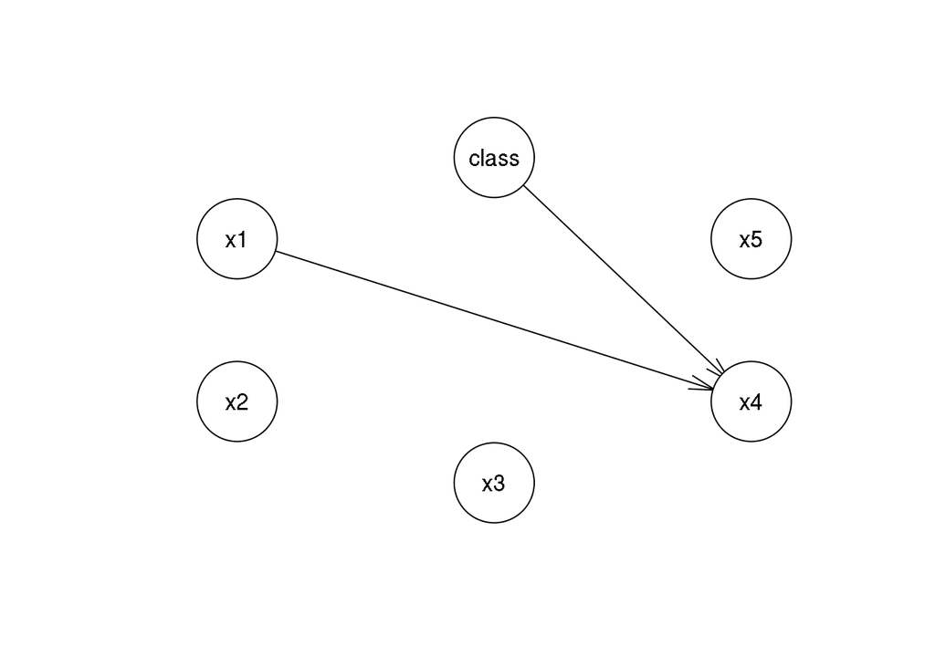

```r
res = tabu(data1,score="bic")
plot(res)
```

```r
fitted <- bn.fit(res,data=data1)
summary(fitted)
```

```
##       Length Class        Mode
## x1    4      bn.fit.dnode list
## x2    4      bn.fit.dnode list
## x3    4      bn.fit.dnode list
## x4    4      bn.fit.dnode list
## x5    4      bn.fit.dnode list
## class 4      bn.fit.dnode list
```

```r
cpquery(fitted,(class==1),(x1=="1" & x4=="0"))
```

```
## [1] 1
```

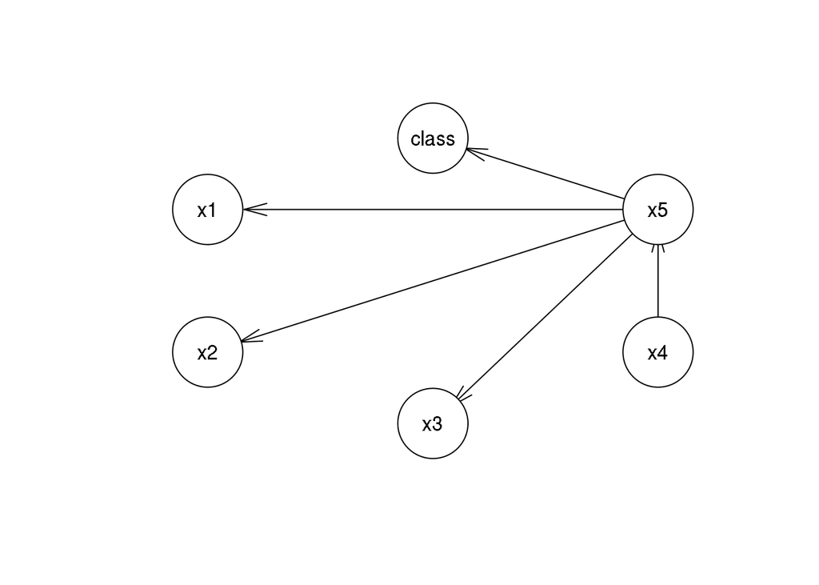

```r
res = tabu(data2,score="bic")
plot(res)
```

```r
fitted <- bn.fit(res,data=data1)
summary(fitted)
```

```
##       Length Class        Mode
## x1    4      bn.fit.dnode list
## x2    4      bn.fit.dnode list
## x3    4      bn.fit.dnode list
## x4    4      bn.fit.dnode list
## x5    4      bn.fit.dnode list
## class 4      bn.fit.dnode list
```

```r
cpquery(fitted,(class==1),(x1=="1" & x4=="0"))
```

```
## [1] 0.5059009
```

Hence, one aims at Minimum-redundancy-maximum-relevance (mRMR) feature selection

This can be implemented in practice in several ways, depending on the way we measure relevance and redundancy. More on this soon. Stay tuned!

## Optimality and relevance.

[figure not shown]